# HW 3

Janna M

5/2/2021

The comparative primate dataset we have used from Kamilar and Cooper has in it a large number of variables related to life history and body size. For this exercise, the end aim is to fit a simple linear regression model to predict weaning age (WeaningAge_d) measured in days from species’ brain size (Brain_Size_Species_Mean) measured in grams. Do the gh following for both weaning age ~ brain size and log(weaning age) ~ log(brain size).

```r
f <- "https://raw.githubusercontent.com/difiore/ada-2021-datasets/main/KamilarAndCooperData.csv"
d <- read_csv(f, col_names = TRUE)
lm_1<-lm(WeaningAge_d ~ Brain_Size_Species_Mean, d)
```

Fit the regression model and, using {ggplot2}, produce a scatterplot with the fitted line superimposed upon the data. Append the the fitted model equation to your plot. HINT: See the function geom_text().

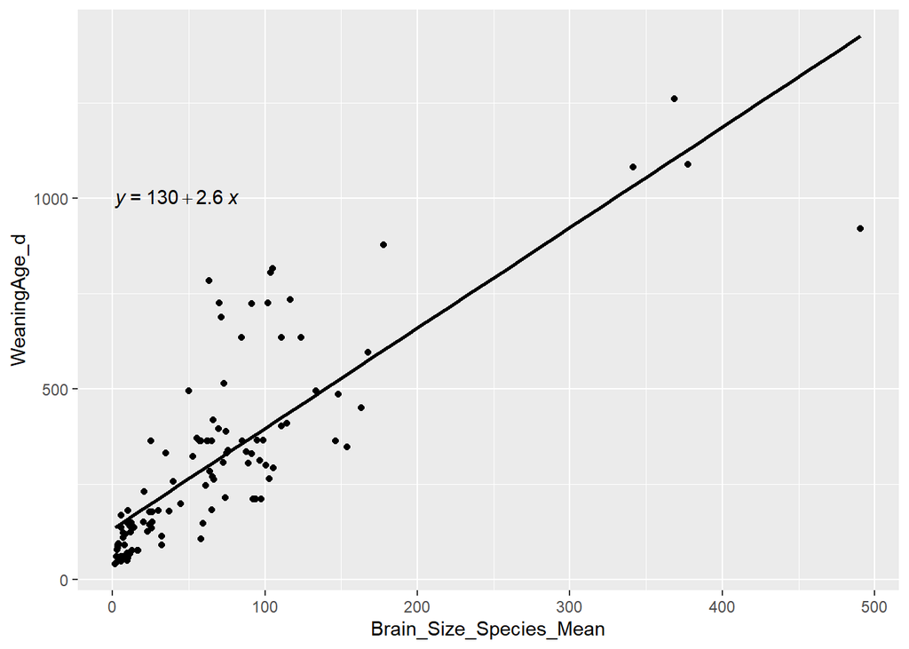

```r
p1 <- ggplot(data = d, aes(x = Brain_Size_Species_Mean, y = WeaningAge_d), na.rm=TRUE) +
geom_point()
p1  <- p1 + geom_smooth(method = 'lm', se= FALSE, color="black" )+
stat_regline_equation(label.y = 1000)
p1
```

Identify and interpret the point estimate of the slope ( β 1 ), as well as the outcome of the test associated with the hypotheses  
H 0 : β 1 = 0 , H A : β 1 ≠ 0 . Also, find a 90% CI for the slope ( β 1 ) parameter. Using your model, add lines for the 90% confidence and prediction interval bands on the plot, and add a legend to differentiate between the lines.

```r
summary.lm(lm_1)
```

```
##
## Call:
## lm(formula = WeaningAge_d ~ Brain_Size_Species_Mean, data = d)
##
## Residuals:
##     Min      1Q  Median      3Q     Max
## -505.38  -90.61  -34.74   48.83  483.77
##
## Coefficients:
##                         Estimate Std. Error t value Pr(>|t|)
## (Intercept)             132.4640    19.1788   6.907 3.69e-10 ***
## Brain_Size_Species_Mean   2.6371     0.1847  14.276  < 2e-16 ***
## ---
## Signif. codes:  0 '***' 0.001 '**' 0.01 '*' 0.05 '.' 0.1 ' ' 1
##
## Residual standard error: 150.5 on 107 degrees of freedom
##   (104 observations deleted due to missingness)
## Multiple R-squared:  0.6557, Adjusted R-squared:  0.6525
## F-statistic: 203.8 on 1 and 107 DF,  p-value: < 2.2e-16
```

```r
upper<-2.6371+1.96*0.1847
lower<-2.6371-1.96*0.1847
upper
```

```
## [1] 2.999112
```

```r
lower
```

```
## [1] 2.275088
```

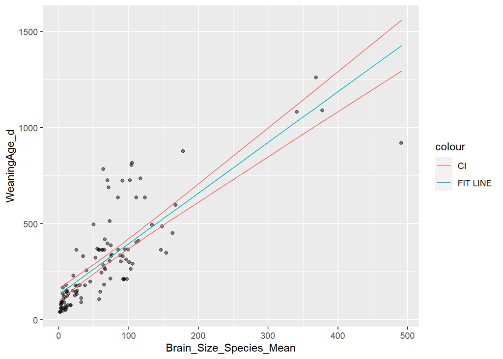

```r
ci<- predict(lm_1,
  newdata = data.frame(Brain_Size_Species_Mean=d$Brain_Size_Species_Mean),
  interval = "confidence", level = 0.9
)
ci<-data.frame(ci)
ci<-cbind(d$Brain_Size_Species_Mean, ci)
names(ci) <- c("brain", "c.fit", "c.lwr", "c.upr")
p1 <- ggplot(data = d, aes(x = Brain_Size_Species_Mean, y = WeaningAge_d), na.rm=TRUE)
p1 <- p1 + geom_point(alpha=0.5)
p1 <- p1 + geom_line(
  data = ci, aes(x = brain, y=c.fit,
  color = "FIT LINE"))
p1 <- p1 + geom_line(
  data=ci, aes(x=brain, y=c.lwr,
  color="CI"))
p1 <- p1 + geom_line(
  data=ci, aes(x=brain, y=c.upr, color="CI"))
p1
```

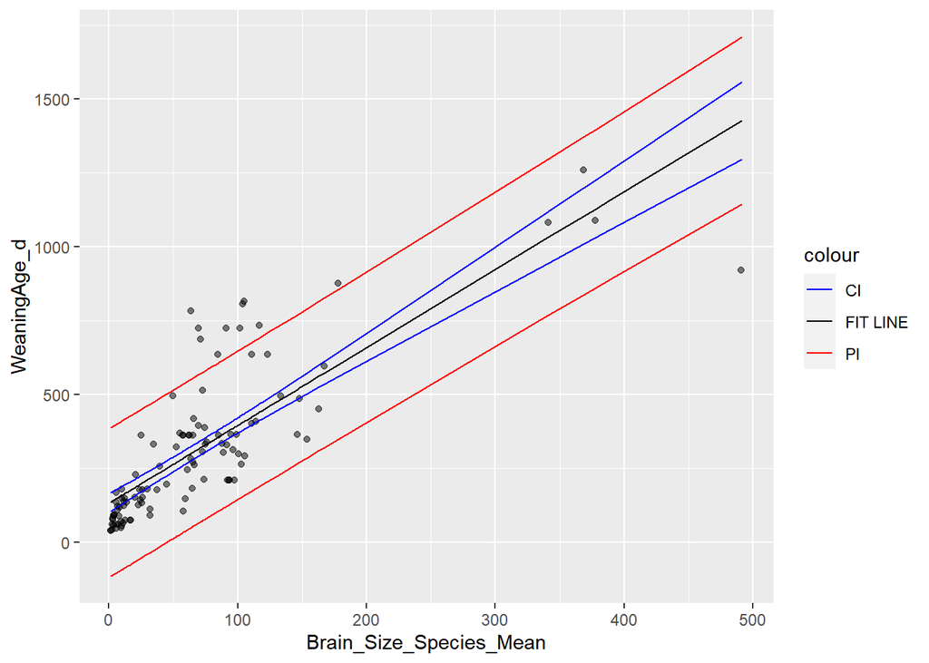

```r
pi<- predict(lm_1,
  newdata = data.frame(Brain_Size_Species_Mean=d$Brain_Size_Species_Mean),
  interval = "prediction", level = 0.9
)
pi <- data.frame(pi)
pi <- cbind(d$Brain_Size_Species_Mean, pi)
names(pi) <-c("brain", "p.fit", "p.lwr", "p.upr")
p1 <- p1 + geom_line(data = pi, aes(x = brain, y = p.lwr, color = "PI"))
p1 <- p1 + geom_line(data = pi, aes(x = brain, y = p.upr, color = "PI"))
p1 <- p1 + scale_color_manual(values=c("blue", "black", "red"))
p1
```

Produce a point estimate and associated 90% prediction interval for the weaning age of a species whose brain weight is 750 gm. Do you trust the model to predict observations accurately for this value of the explanatory variable? Why or why not? Looking at your two models (i.e., untransformed versus log-log transformed), which do you think is better? Why?

```r
point <- predict(lm_1,
newdata = data.frame(Brain_Size_Species_Mean = 750),
interval = "confidence", level = 0.9
)
point
```

```
##        fit     lwr      upr
## 1 2110.294 1900.04 2320.548
```

```r
d$Brain_Size_Species_Mean<-(log(d$Brain_Size_Species_Mean))
d$WeaningAge_d<-(log(d$WeaningAge_d))
lm_2<-lm(WeaningAge_d ~ Brain_Size_Species_Mean, d)
summary.lm(lm_2)
```

```
##
## Call:
## lm(formula = WeaningAge_d ~ Brain_Size_Species_Mean, data = d)
##
## Residuals:
##     Min      1Q  Median      3Q     Max
## -1.0244 -0.2523 -0.0131  0.3225  0.9228
##
## Coefficients:
##                         Estimate Std. Error t value Pr(>|t|)
## (Intercept)              3.36985    0.11671   28.88   <2e-16 ***
## Brain_Size_Species_Mean  0.57116    0.03061   18.66   <2e-16 ***
## ---
## Signif. codes:  0 '***' 0.001 '**' 0.01 '*' 0.05 '.' 0.1 ' ' 1
##
## Residual standard error: 0.4108 on 107 degrees of freedom
##   (104 observations deleted due to missingness)
## Multiple R-squared:  0.765,  Adjusted R-squared:  0.7628
## F-statistic: 348.3 on 1 and 107 DF,  p-value: < 2.2e-16
```

```r
upper<- 0.57116+1.96*0.03061
lower<- 0.57116-1.96*0.03061
upper
```

```
## [1] 0.6311556
```

```r
lower
```

```
## [1] 0.5111644
```

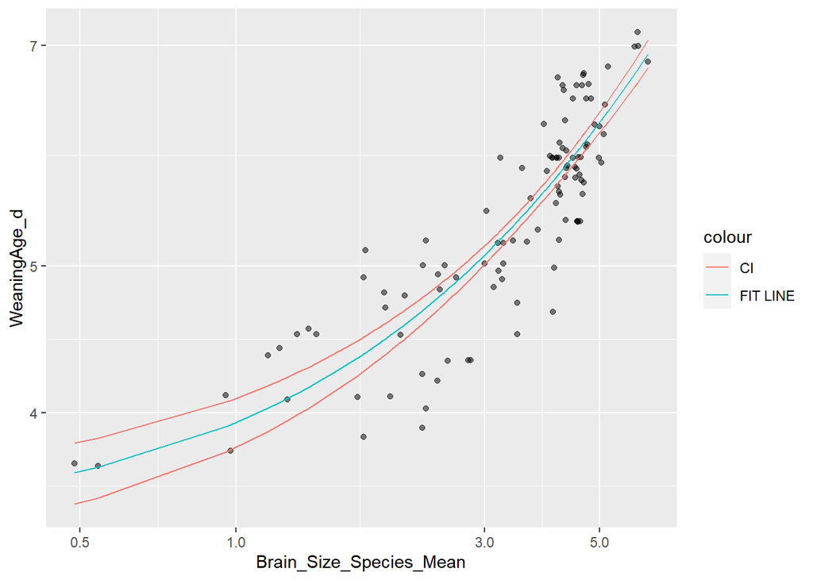

```r
ci<- predict(lm_2,
newdata = data.frame(Brain_Size_Species_Mean=d$Brain_Size_Species_Mean),
interval = "confidence", level = 0.9
)
ci<-data.frame(ci)
ci<-cbind(d$Brain_Size_Species_Mean, ci)
names(ci) <- c("brain", "c.fit", "c.lwr", "c.upr")
p2 <- ggplot(data = d, aes(x = Brain_Size_Species_Mean, y = WeaningAge_d), na.rm=TRUE)
p2 <- p2 + geom_point(alpha=0.5)
p2 <- p2 + geom_line(
data = ci, aes(x = brain, y=c.fit,
color = "FIT LINE"))
p2 <- p2 + geom_line(
data=ci, aes(x=brain, y=c.lwr,
color="CI"))
p2 <- p2 + geom_line(
data=ci, aes(x=brain, y=c.upr, color="CI"))
p2 <- p2 + scale_y_continuous(trans='log10')
p2 <- p2 + scale_x_continuous(trans='log10')
p2
```